# DMA - Lab Task #1

Viet Ba Mai

11 października 2016

# File Import

```r
allegro_trans <- read.csv(file="C:/Users/vietba/Documents/Computer Science/Masters/II/Data Mining Advances/Homeworks/Lab 1/allegro-api-transactions.csv", header=TRUE, sep=",", encoding="UTF-8")

allegro_cat <- read.table("C:/Users/vietba/Documents/Computer Science/Masters/II/Data Mining Advances/Homeworks/Lab 1/allegro-categories-eng.txt", header=TRUE, sep=";", quote=NULL, comment="", encoding="UTF-8")
```

## Tables

Below 10 first observations of each imported tables are presented.

1. Allegro Transactions

```
##    lp                date    item_id
## 1   0 2016-04-03 21:21:08 4753602474
## 2   1 2016-04-03 15:35:26 4773181874
## 3   2 2016-04-03 14:14:31 4781627074
## 4   3 2016-04-03 19:55:44 4783971474
## 5   4 2016-04-03 18:05:54 4787908274
## 6   5 2016-04-03 16:31:01 4790991674
## 7   6 2016-04-03 17:56:11 4790991674
## 8   7 2016-04-03 11:58:55 4824025074
## 9   8 2016-04-03 18:18:37 4826332874
## 10  9 2016-04-03 22:56:56 4828603874
##                                                                                            categories
## 1               ['Komputery', 'Dyski i napędy', 'Nośniki', 'Nośniki DVD-R/RW', '30-50 szt. DVD-R/RW']
## 2                                            ['Odzież, Obuwie, Dodatki', 'Bielizna damska', 'Majtki']
## 3             ['Dom i Ogród', 'Budownictwo i Akcesoria', 'Ściany i elewacje', 'Tapety', 'Fototapety']
```

[output cut: 40 more lines]

2. Allegro Categories (eng)

```
##     X.U.FEFF.main_category                    main_category_eng
## 1                Komputery                            Computers
## 2  Odzież, Obuwie, Dodatki         Clothing, Shoes, Accessories
## 3              Dom i Ogród                        Home & Garden
## 4        Książki i Komiksy    Books and Comics
## 5      Biżuteria i Zegarki                    Jewelry & Watches
## 6                RTV i AGD    RTV & AGD
## 7              Motoryzacja                           Automotive
## 8               Dla Dzieci       Babies
## 9                    Uroda                               Beauty
## 10    Telefony i Akcesoria  Phones & Accessories
```

# Lookup Table and Translation

In the following case we will make use of the dplyr library.

## Joining the tables with left_join

```r
#install.packages("dplyr")

library(dplyr)
allegro_eng <- left_join(allegro_trans, allegro_cat, by = c("main_category" = "X.U.FEFF.main_category"))
```

## Merged tables result

To make the result clearer the number of columns selected was restricted to 3.

```
##       item_id           main_category                  main_category_eng
## 1  4753602474               Komputery                          Computers
## 2  4773181874 Odzież, Obuwie, Dodatki       Clothing, Shoes, Accessories
## 3  4781627074             Dom i Ogród                      Home & Garden
## 4  4783971474       Książki i Komiksy  Books and Comics
## 5  4787908274 Odzież, Obuwie, Dodatki       Clothing, Shoes, Accessories
## 6  4790991674 Odzież, Obuwie, Dodatki       Clothing, Shoes, Accessories
## 7  4790991674 Odzież, Obuwie, Dodatki       Clothing, Shoes, Accessories
## 8  4824025074     Biżuteria i Zegarki                  Jewelry & Watches
## 9  4826332874               RTV i AGD  RTV & AGD
## 10 4828603874               RTV i AGD  RTV & AGD
```

# Summaries

In this section summaries of the following variables will be done: - price

-it_is_allegro_standard

-it_is_brand_zone

-it_seller_rating

-date

We need to select top 5 categories hence we will find the frequencies of each category and then filter to only the best 5.

```
##
##                            Home & Garden
##                                    91042
##             Clothing, Shoes, Accessories
##                                    54257
##                               Automotive
##                                    45941
##           Babies
##                                    42107
##                                   Beauty
##                                    28096
##                          Sport & Tourism
##                                    27532
##        RTV & AGD
##                                    20341
##      Phones & Accessories
##                                    19805
##                                Computers
##                                    14491
##        Health
##                                    13166
##        Books and Comics
##                                    11572
##       Delicatessen
##                                     8074
##     Games
##                                     7150
##                                   Crafts
##                                     6574
##                              Collections
##                                     6146
##                                 Industry
##                                     5959
##                        Jewelry & Watches
##                                     5808
##  Office & Advertising
##                                     3194
##                              Photography
##                                     2381
##        Music
##                                     1961
##                          Antiques & Arts
##                                     1214
##                                 Consoles
##                                     1053
##       FIlms
##                                     1005
##                              Instruments
##                                      617
##                    Technics, studio & DJ
##                                      413
##      Tickets
##                                      119
##                              Real Estate
##                                        2
```

Now we can see that the top 5 categories are: 1. Home & Garden 2. Clothing, Shoes, Accessories 3. Automotive 4. Babies 5. Beauty

And will create a new table with only these categories.

```r
top5 <- c(" Home & Garden", " Clothing, Shoes, Accessories", " Automotive", " Babies", " Beauty")
allegro_trans_top <- subset(allegro_eng, allegro_eng$main_category_eng %in% top5)
```

## Numerical Summaries

### Categorical Variables

1. Is Allegro Standard:

```
##
##      1      0
## 129426  89910
```

2. Brand Zone:

```
##
##      0      1
## 216173   3163
```

3. Transaction Date:

```
##
## 2016-04-03 22:32:33 2016-04-03 20:16:26 2016-04-03 22:32:46
##                 105                  95                  77
## 2016-04-03 22:32:28 2016-04-03 16:44:50
##                  72                  69
##  [ reached getOption("max.print") -- omitted 38948 entries ]
```

The number of output was limited to 5.

### Continuous Variables

1. Price:

```
##      Min.   1st Qu.    Median      Mean   3rd Qu.      Max.
##      0.00      9.50     27.00     80.59     78.00 119000.00
```

2. Seller Rating:

```
##    Min. 1st Qu.  Median    Mean 3rd Qu.    Max.
##      -1    1624    6711   19020   20790  260200
```

## Graphical Summaries

### Categorical Variables

1. Is Allegro Standard:

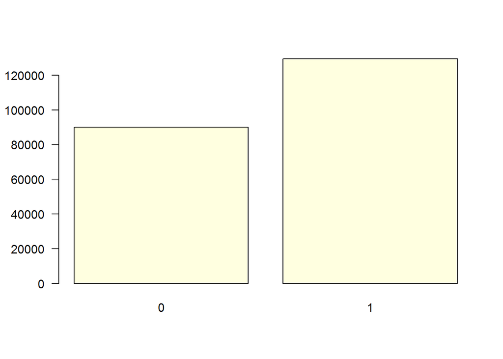

2. Brand Zone:

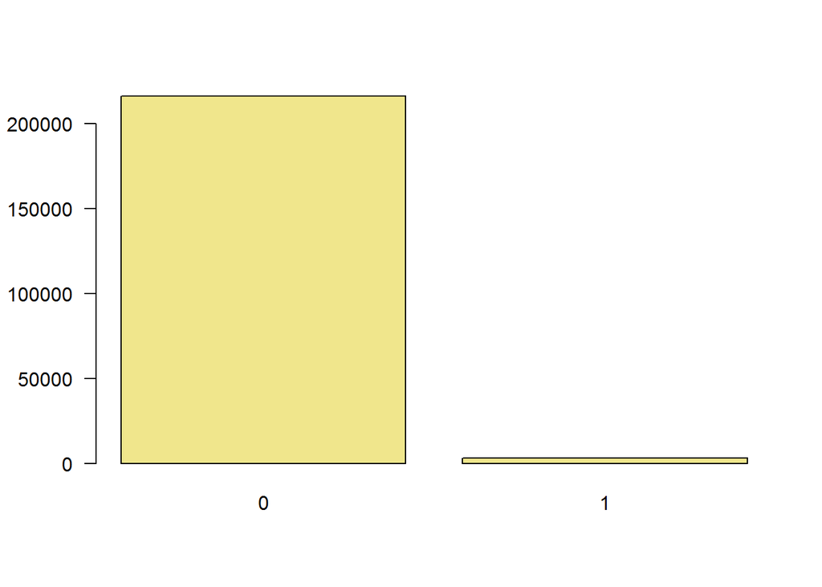

### Continuous Variables

1. Price:

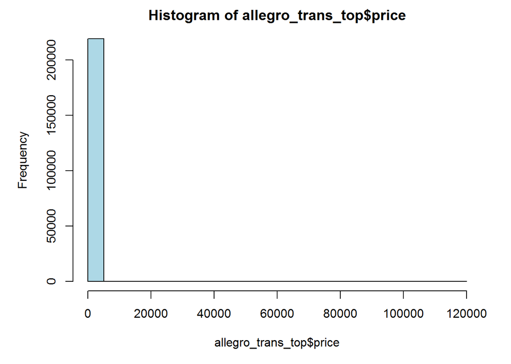

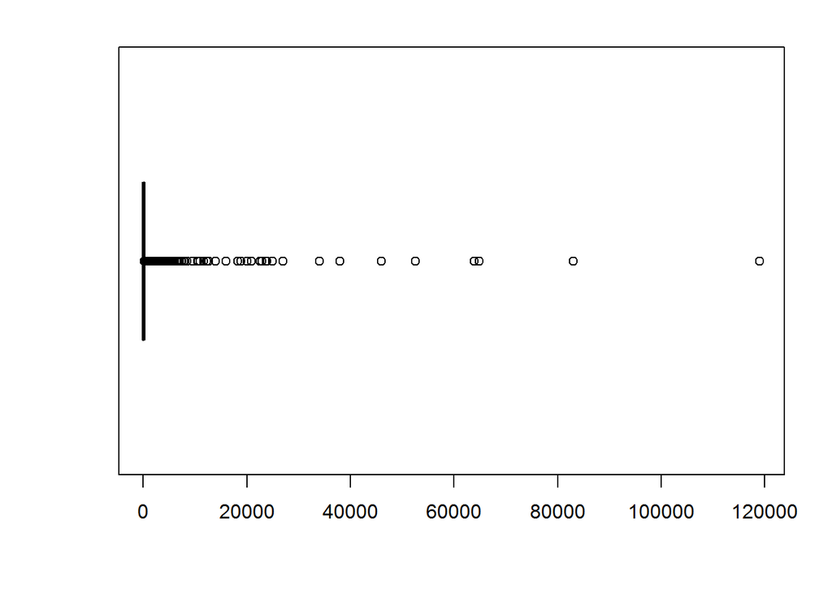

2. Seller Rating:

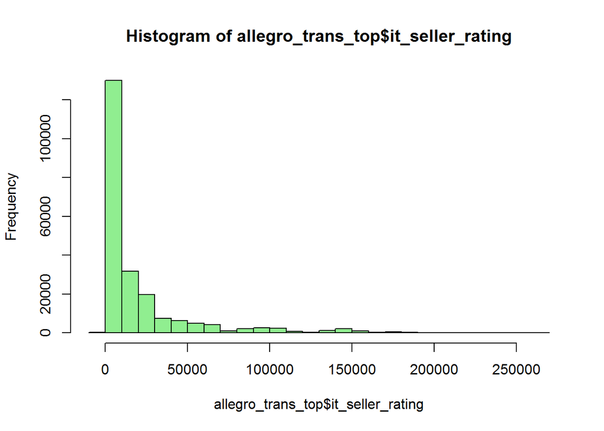

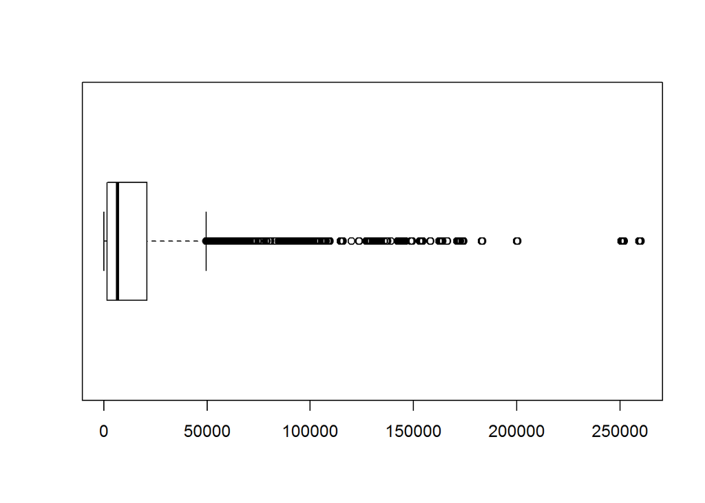

## 2-variable representations

### Numerical Summaries for different discrete variables

1. Price by Brand Zone:

```
## allegro_trans_top$it_is_brand_zone: 0
##      Min.   1st Qu.    Median      Mean   3rd Qu.      Max.
##      0.00      9.45     26.50     79.10     74.99 119000.00
## --------------------------------------------------------
## allegro_trans_top$it_is_brand_zone: 1
##    Min. 1st Qu.  Median    Mean 3rd Qu.    Max.
##    1.19   49.90  140.00  182.40  229.00 3995.00
```

2. Seller Rating by Brand Zone:

```
## allegro_trans_top$it_is_brand_zone: 0
##    Min. 1st Qu.  Median    Mean 3rd Qu.    Max.
##      -1    1623    6693   18780   20790  260200
## --------------------------------------------------------
## allegro_trans_top$it_is_brand_zone: 1
##    Min. 1st Qu.  Median    Mean 3rd Qu.    Max.
##       0    2148    8562   35020   15660  133600
```

3. Price by Allegro Standard:

[output not shown]

4. Seller Rating by Allegro Standard:

[output not shown]

## Graphical summary of continuous variables.

Seller Rating and Price:

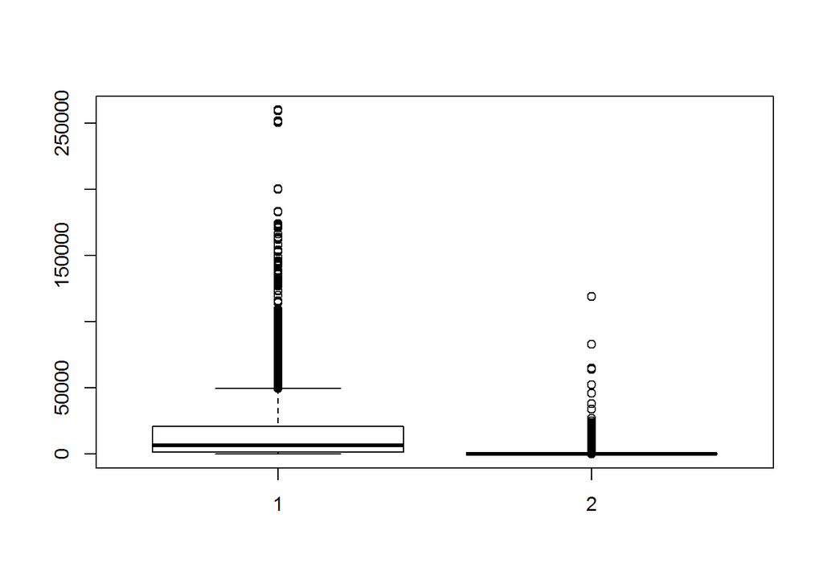

# Conclusions

Most of items are of Allegro standard and in Brand Zone 0. On 2016-04-03 22:32:33 the most number of recorded transactions were made with the value being 105. Following that were transactions made around 2 hours earlier with the number being 95.

The mean price of items is 80.59 while the maximum found is 119000.00. On average the seller’s rating is 19020. The mean prices are higher in zone 1, but the maximum price was recorded in the zone 0. On the other hand the seller rating is greater in the zone 1.